# Recalling Words

#### Background

Many teachers and other educators are interested in understanding how to best deliver new content to students. In general, they have two choices of how to do this.

1. The Meshed Approach
   - Deliver new content while simultaneously reviewing previously understood content.
2. The Before Approach
   - Deliver new content after fully reviewing previously understood content.

A study was performed to determine whether the *Meshed* or *Before* approaches to delivering content had any positive benefits on memory recall.

##### The Experiment (click to view)

# Analysis

For this particular analysis I am interested in the comparing the Before and Meshed approaches.
$$H_0: {\text{difference in medians}} = 0$$
$$H_a: {\text{difference in medians}} \ne 0$$

There are only 10 results from each of the tests and the data is not normally distributed for the Before approach, and only partially normal for the Meshed approach.

Because of this, using a Wilcoxon rank sum test would be a good fit. The significance level will be set at 0.05.

```r
pander(wilcox.test(correct ~ condition, data=set2, paired=FALSE, mu=0, alternative="two.sided", conf.level=.95))
```

Wilcoxon rank sum test with continuity correction: `correct` by `condition`

| Test statistic | P value | Alternative hypothesis |
| --- | --- | --- |
| 62 | 0.378 | two.sided |

**Table summary:**

```r
pander(favstats(correct ~ condition, data=set2))
```

| condition | min | Q1 | median | Q3 | max | mean | sd | n | missing |
| --- | --- | --- | --- | --- | --- | --- | --- | --- | --- |
| Before | 24 | 37.25 | 39 | 39.75 | 40 | 36.6 | 5.337 | 10 | 0 |
| Meshed | 30 | 36 | 36.5 | 38.75 | 40 | 36.6 | 3.026 | 10 | 0 |

**Graphical summary:**

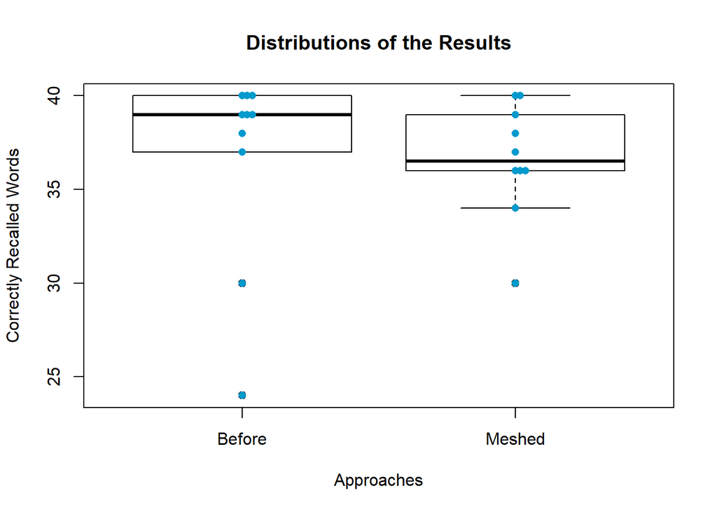

```r
boxplot(correct ~ condition, data=rev(set2), horizontal=F, las=0, xlab="Approaches", ylab="Correctly Recalled Words", main="Distributions of the Results")
stripchart(correct ~ condition, data=set2, add=TRUE, pch=16, col="deepskyblue3", vertical=T, method="stack")
```

# Interpretation

The table summary includes that the results from the Before method have a higher median score (39) than the results from the Meshed (36.5).  
The p-value from the analysis however, is 0.378. This is well above 0.05, so we can not claim sufficient evidence that there is a difference in recollection between the Before and Meshed approaches.  
If another experiment was conducted with more participants, then a more certain comparison could be obtained. I might suggest however, that if this research is continued, an experiment would be most valuable conducted dirrectly in the classrooms.

We could observe however, if both methods are better than the SFR (control) method: